# Chapitre 1 — Données financières et faits stylisés

Économétrie Financière · M2

Bilel Sanhaji

**Objectifs du chapitre**

- Définir l’économétrie financière et son cadre (échantillon, DGP, modèle)
- Distinguer prix et rendements, rendement simple et log-rendement
- Caractériser une distribution par ses moments (moyenne, variance, asymétrie, kurtosis)
- Reconnaître les faits stylisés des séries financières — en particulier ceux qui motivent les modèles ARCH/GARCH du chapitre 3

# Introduction

## Qu’est-ce que l’économétrie financière ?

**Économétrie financière** : application de méthodes statistiques aux données des marchés financiers. Elle se distingue des autres formes d’économétrie par l’accent mis sur l’analyse des prix d’actifs négociés sur des marchés compétitifs et liquides.

> « L’économétrie est l’analyse quantitative des phénomènes économiques réels basée sur le développement conjoint de la théorie et de l’observation, reliés par des méthodes d’inférence appropriées. » — Samuelson, Koopmans et Stone (1954)

Objectifs : combiner théorie financière et théorie statistique, modéliser les données financières, prédire les variables financières, développer des modèles adaptés aux faits stylisés (ex. : GARCH — Prix Nobel 2003, R.F. Engle).

## Les quatre piliers de l’économétrie (financière)

1. Un **échantillon** de données
2. Un **modèle économétrique**
3. Une **méthode d’estimation**
4. Des **méthodes d’inférence**

**Processus Générateur de Données (DGP)** : distribution de probabilité conjointe supposée caractériser toute la population dont l’échantillon est extrait. Le défi de l’économétrie est de tirer des conclusions sur le DGP (paramètres inconnus) à partir d’une seule réalisation observée.

Population (paramètres inconnus) $\to$ Échantillon $\to$ Statistique d’échantillon (estimateur) $\to$ **Inférence**.

## Modèle paramétrique vs non paramétrique

**Modèle paramétrique** : la relation entre $Y$ et $X$ est entièrement caractérisée par un ensemble fini de paramètres $\theta$ :
$$Y = f(X;\theta) + \epsilon$$
avec $f(\cdot)$ connue. Dans un modèle **non paramétrique**, $f(\cdot)$ est inconnue et doit elle-même être estimée.

Démarche générale : (1) spécification du modèle, (2) estimation des paramètres, (3) tests de diagnostic (significativité, spécification, rétrovalidation), (4) interprétation et utilisation (prévision).

Tous les modèles de ce cours (ARMA, GARCH) sont **paramétriques**.

# Données financières

## Prix et fréquence d’échantillonnage

Soit $P_t$ le prix d’un actif au temps $t$. Les marchés « liquides » (changes, indices, grandes capitalisations) enregistrent les prix plusieurs fois par minute.

Fréquences **régulières** : les prix sont observés tous les $m$ pas de temps. On distingue les fréquences **intrajournalières** (haute fréquence : 10 secondes, 1 minute, 5 minutes…) des fréquences plus **basses** (journalière, hebdomadaire, mensuelle…).

Ce cours travaille exclusivement à fréquence **régulière**, le plus souvent journalière — c’est la fréquence à laquelle l’effet ARCH est le plus marqué (chapitre 3).

## Prix de clôture, prix ajustés

- **Prix d’ouverture** : prix à l’ouverture de la séance.
- **Prix de clôture** : prix final de la séance — c’est le prix généralement retenu pour une fréquence journalière.
- **Prix ajustés** : corrigés des fractionnements d’actions et des dividendes (les dividendes sont réintégrés comme s’ils étaient immédiatement réinvestis).

Toujours vérifier si une série téléchargée (Yahoo Finance, etc.) est en prix bruts ou en prix ajustés — les rendements calculés diffèrent sensiblement en présence de détachements de dividendes.

## Prix vs rendements

Bien que les **prix** soient ce qui est observé, la plupart des études empiriques portent sur les **rendements** :

- Résumé **sans échelle** de l’opportunité d’investissement.
- Propriétés statistiques plus attractives que les prix.
- Les prix sont en général **non stationnaires**, les rendements **stationnaires** (fait stylisé 1, plus loin).

## Rendement simple et log-rendement

**Rendement simple (net)** :
$$\tilde R_t = \frac{P_t - P_{t-1}}{P_{t-1}}$$

**Rendement composé continûment (log-rendement)** :
$$R_t = \ln\left(\frac{P_t}{P_{t-1}}\right) = p_t - p_{t-1}$$
où $p_t = \ln P_t$.

Les deux sont très proches quand $\tilde R_t$ est proche de 0 :
$$R_t = \ln(1+\tilde R_t) \simeq \tilde R_t \quad \text{si } \tilde R_t \simeq 0$$

Convention du cours : sauf mention contraire, $R_t$ désigne le **log-rendement**. Les log-rendements s’additionnent dans le temps — pas les rendements simples — ce qui les rend commodes pour l’agrégation temporelle (slide suivante).

## Rendement à $k$ périodes et rendement annualisé

$$R_t[k] = \sum_{j=0}^{k-1} R_{t-j}[1] = \ln\left(\frac{P_t}{P_{t-k}}\right)$$

Preuve : la multiplication des rapports de prix devient une somme de logarithmes — c’est l’intérêt pratique majeur du log-rendement.

**Rendement annualisé** (moyen), détention sur $k$ années :
$$\text{Annualisé}(R_t[k]) = \frac1k\sum_{j=0}^{k-1}R_{t-j}[1]$$

Un actif a un rendement journalier moyen de $0{,}013\%$. Quel est son rendement annualisé (base 365 jours) ? *(Réponse : $365\times0{,}013\% \approx 4{,}75\%$.)*

**Rendement excédentaire** : $R_t - R_{f,t}$, où $R_{f,t}$ est un taux de référence (taux sans risque).

# Propriétés statistiques des rendements

## Distribution des rendements

$R_t$ est une variable aléatoire à valeurs réelles, de densité $f_R(r)$ et de fonction de répartition $F_R(r) = \Pr(R_t\le r)$.

**Hypothèse de normalité** :
$$R_t \sim \mathcal N(\mu,\sigma^2), \qquad
f_R(r) = \frac1{\sigma\sqrt{2\pi}}\exp\!\left(-\frac{(r-\mu)^2}{2\sigma^2}\right)$$

C’est l’hypothèse de référence — et celle que les faits stylisés (section suivante) vont largement invalider empiriquement.

## Les quatre premiers moments

Moment non centré : $m_k=\mathbb E(R_t^k)$. Moment centré : $\mu_k=\mathbb E\big((R_t-m_1)^k\big)$.

| Moment | Formule | Interprétation |
| --- | --- | --- |
| Moyenne | $\mu=\mathbb E(R_t)$ | tendance centrale |
| Variance | $\sigma^2=\mathbb E\big((R_t-\mu)^2\big)$ | dispersion |
| Asymétrie | $S=\mathbb E\big((R_t-\mu)^3\big)/\sigma^3$ | symétrie |
| Kurtosis | $K=\mathbb E\big((R_t-\mu)^4\big)/\sigma^4$ | épaisseur des queues |

**Volatilité** $\equiv \sigma = \sqrt{\mathbb V(R_t)}$ : c’est l’objet central du chapitre 3.

## Asymétrie et kurtosis : interprétation

- $S(R_t) < 0$ : distribution **asymétrique à gauche** — les grandes réalisations négatives (krachs) sont plus probables que les grandes réalisations positives.
- $K(R_t) > 3$ : distribution **leptokurtique** (queues épaisses) — $K=3$ : mésokurtique, $K<3$ : platykurtique.
- **Excès de kurtosis** $\equiv K(R_t) - 3$.

Sous normalité : $S(R_t)=0$ et $K(R_t)=3$ — toujours, quelle que soit la variance. Sous une loi de Student à $\nu$ degrés de liberté ($\nu>4$) :
$$S(R_t)=0, \qquad K(R_t)=3+\frac6{\nu-4}$$
symétrique mais leptokurtique ; $K\to3$ quand $\nu\to\infty$ (la Student tend vers la normale).

## Estimateurs des moments

Échantillon $\{R_1,\dots,R_T\}$ i.i.d., réalisation $\{r_1,\dots,r_T\}$ = le jeu de données.

$$\widehat\mu_T=\overline R_T=\frac1T\sum_{t=1}^T R_t, \qquad
\widehat\sigma_T^2=\frac1{T-1}\sum_{t=1}^T(R_t-\overline R_T)^2$$

$$\widehat S_T=\frac{T^{-1}\sum_t(R_t-\overline R_T)^3}{\widehat\sigma_T^3}, \qquad
\widehat K_T=\frac{T^{-1}\sum_t(R_t-\overline R_T)^4}{\widehat\sigma_T^4}$$

Un estimateur $\widehat\theta$ est lui-même une **variable aléatoire** — il a une distribution d’échantillonnage. C’est ce qui permet de construire des tests et intervalles de confiance (slide suivante).

## Comportement asymptotique

Si $R_1,\dots,R_T$ i.i.d. avec moments finis, les moments d’échantillon **convergent en probabilité** :
$$\widehat\mu_T\xrightarrow{p}\mu, \quad
\widehat\sigma_T^2\xrightarrow{p}\sigma^2, \quad
\widehat S_T\xrightarrow{p}S(R_t), \quad
\widehat K_T\xrightarrow{p}K(R_t)$$

Sous normalité, **distributions asymptotiques** ($T\to\infty$) :
$$\sqrt T(\widehat\mu_T-\mu)\overset{d}{\to}\mathcal N(0,\sigma^2), \qquad
\sqrt T(\widehat S_T-0)\overset{d}{\to}\mathcal N(0,6), \qquad
\sqrt T(\widehat K_T-3)\overset{d}{\to}\mathcal N(0,24)$$

## Mesures robustes de dispersion

**MAD** (Median Absolute Deviation) :
$$\text{MAD} = \text{médiane}\big(|r_t - \text{médiane}(r_t)|\big)$$

**IQR** (écart interquartile) : $\text{IQR} = Q(0{,}75) - Q(0{,}25)$.

Deux mesures de dispersion **robustes** aux valeurs aberrantes — utiles quand la présence de queues épaisses (fait stylisé 3) rend l’écart-type sensible aux quelques observations extrêmes.

# Faits stylisés

## Huit faits stylisés (Fan et Yao, 2015)

1. Stationnarité
2. Absence d’autocorrélation (des rendements)
3. Queues épaisses
4. Asymétrie
5. Clustering de la volatilité
6. Gaussianité agrégative
7. Dépendance à longue mémoire
8. Effet de levier

*Fan, J. et Yao, Q. (2015), The Elements of Financial Econometrics.* *Cont, R. (2001), Empirical Properties of Asset Returns, Quantitative Finance.*

## Fait 1 : Stationnarité

Les **prix** sont en général non stationnaires (tendance, crises), les **rendements** sont (faiblement) stationnaires.

**Stationnarité faible (ordre 2)** : $\{x_t\}$ est faiblement stationnaire ssi

1. $\forall t,\ \mathbb E(x_t^2) < \infty$
2. $\forall t,\ \mathbb E(x_t) = \mu$ ne dépend pas de $t$
3. $\forall (t,h),\ \mathrm{Cov}(x_t,x_{t+h}) = \gamma_h$ ne dépend pas de $t$

C’est l’hypothèse de travail de tout le cours : ARMA (chapitre 2) et GARCH (chapitre 3) supposent tous deux une stationnarité (faible ou en covariance) des séries modélisées.

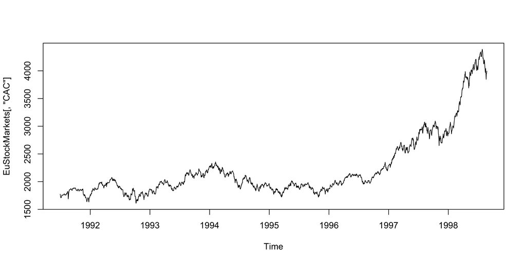

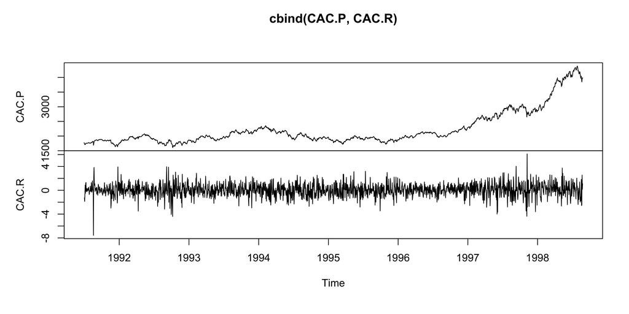

## Fait 2 : Absence d’autocorrélation

Les autocorrélations des rendements $R_t$ sont en général non significatives (sauf microstructure à très haute fréquence).

L’absence d’autocorrélation des rendements **ne signifie pas** que les $R_t$ sont indépendants — voir le fait stylisé 7 (mémoire longue des rendements au **carré**).

$$\rho_k = \mathrm{Corr}(R_t,R_{t-k}) = \frac{\gamma_k}{\sigma^2}, \qquad
\widehat\rho_k = \frac1{(T-k)\sigma^2}\sum_{t=k+1}^T(R_t-\widehat\mu)(R_{t-k}-\widehat\mu)$$

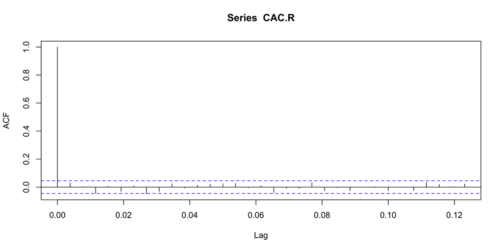

### Tests Q : Box-Pierce et Ljung-Box

$H_0: \rho_1=\dots=\rho_K=0$ contre $H_1: \exists j,\ \rho_j\ne0$.

**Box-Pierce** : $\displaystyle Q_{BP}=T\sum_{k=1}^K\widehat\rho_k^2 \overset{H_0}{\sim}\chi^2(K)$

**Ljung-Box** (plus utilisé en pratique) :
$$Q_K = T(T+2)\sum_{k=1}^K\frac{\widehat\rho_k^2}{T-k} \overset{H_0}{\sim}\chi^2(K)$$

Règle de décision usuelle : rejet de $H_0$ si $Q >$ quantile $\chi^2(K)$ à $95\%$, ou p-valeur $<5\%$.

```
    Box-Pierce test

data:  CAC.P
X-squared = 1846.3, df = 1, p-value < 2.2e-16
```

```
    Box-Pierce test

data:  CAC.R
X-squared = 1.6381, df = 1, p-value = 0.2006
```

## Fait 3 : Queues épaisses

La distribution des rendements a des queues plus épaisses qu’une distribution normale (excès de kurtosis $K-3 > 0$).

Test de kurtosis : $H_0: K(R_t)=3$ contre $H_1: K(R_t)>3$.
$$\frac{\widehat K_T - 3}{\sqrt{24/T}} \overset{H_0}{\sim} \mathcal N(0,1)$$

Un indice affiche $\widehat K_T = 8{,}9$ sur $T=1255$ observations. Tester $H_0$ au seuil $5\%$ (valeur critique $\Phi^{-1}(0{,}95)=1{,}645$). *(Réponse : statistique très supérieure à 1,645 $\Rightarrow$ rejet de $H_0$ $\Rightarrow$ distribution leptokurtique — cas quasi systématique sur données financières journalières.)*

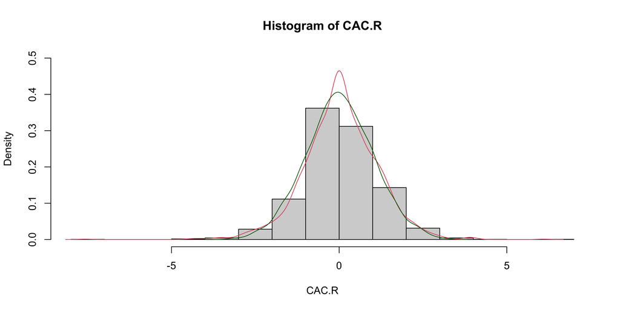

```
[1] 2.379624
```

```
[1] -0.1772549
```

## Fait 4 : Asymétrie

La distribution des rendements est souvent **asymétrique à gauche** : les baisses de marché sont plus abruptes que les reprises, les investisseurs réagissent plus fortement aux mauvaises nouvelles.

Test d’asymétrie : $H_0: S(R_t)=0$ contre $H_1: S(R_t)<0$.
$$\frac{\widehat S_T}{\sqrt{6/T}} \overset{H_0}{\sim} \mathcal N(0,1)$$

Règle de décision : rejet si la statistique est **inférieure** au quantile $\Phi^{-1}(0{,}05) = -1{,}645$, ou p-valeur $<5\%$.

## Fait 5 : Clustering de la volatilité

Les grands changements de prix (en valeur absolue) tendent à être suivis de grands changements de prix ; les périodes calmes alternent avec des périodes agitées.

Ce clustering est la manifestation visuelle directe de l’**autocorrélation des rendements au carré** (fait stylisé 7). C’est *l’observation* empirique que les modèles ARCH/GARCH du chapitre 3 formalisent.

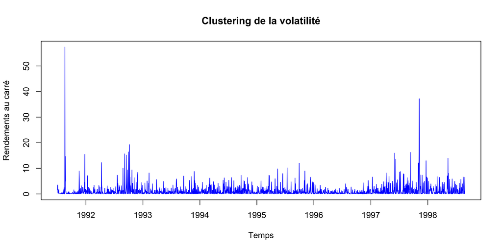

## Fait 6 : Gaussianité agrégative

Un rendement à $k$ jours est l’agrégation de $k$ rendements journaliers. Quand $k$ augmente, la loi des grands nombres joue et la distribution des rendements sur un horizon plus long (mensuel) se rapproche d’une normale.

**Test de Jarque-Bera** : $H_0: S(R_t)=0$ et $K(R_t)=3$.
$$JB = \frac T6\widehat S_T^2 + \frac T{24}(\widehat K_T-3)^2 \overset{H_0}{\sim}\chi^2(2)$$

Le test de Jarque-Bera **n’est pas** un test de normalité au sens strict : le rejet de $H_0$ implique que $R_t$ n’est pas normal, mais la non-rejet n’implique que symétrie + mésokurtique (d’autres lois partagent ces deux propriétés). Valeur critique à $5\%$ : $5{,}9915$.

## Fait 7 : Dépendance à longue mémoire

Les rendements **absolus** et **au carré** présentent des autocorrélations significatives et persistantes (contrairement aux rendements bruts, fait stylisé 2).

**Effet ARCH** $\equiv$ autocorrélation des rendements au carré. Il est plus marqué à haute fréquence (journalier) et s’atténue aux fréquences plus basses (mensuel, trimestriel). C’est ce fait précis que teste formellement le test d’Engle (1982), chapitre 3.

## Fait 8 : Effet de levier

Les rendements sont **négativement corrélés** avec les variations de leur propre volatilité.

- Quand les prix baissent, le ratio dette/fonds propres des entreprises augmente $\Rightarrow$ risque et volatilité augmentent.
- Volatilité en hausse $\Rightarrow$ rendement exigé plus élevé $\Rightarrow$ pression baissière sur les prix.
- Asymétrie de l’effet : la hausse de volatilité suite à une baisse de prix est typiquement plus forte que la baisse de volatilité suite à une hausse de même ampleur.

# Références

- Campbell, J.Y., Lo, A.W., MacKinlay, A.C. (1997). *The Econometrics of Financial Markets*. Princeton University Press.
- Cont, R. (2001). Empirical Properties of Asset Returns: Stylized Facts and Statistical Issues. *Quantitative Finance*, 1, 223-236.
- Fan, J., Yao, Q. (2015). *The Elements of Financial Econometrics*. Science Press, Beijing.
- Brooks, C. (2014). *Introductory Econometrics for Finance*, 3ᵉ édition. Cambridge University Press.
- Tsay, R. (2002). *Analysis of Financial Time Series*. Wiley.